# Marcaje-reavistamiento espacial generalizado (gSMR)

José Jiménez (CSIC-IREC) email: jose.jimenez@csic.es

04/8/2022

## Introducción

Los modelos de marcaje-reavistamiento espacialmente explícito (SMR) fueron desarrollados originalmente por Sollmann et al. (2013) como extensiones de los SCR. Se utilizan en los casos donde no una parte de los individuos está marcada y otra no. Con estas marcas i) se puede separar la población en los eventos de avistamiento, diferenciando entre el animales marcados y no marcados, y ii) se pueden reconocer individualmente los animales marcados. Las marcas pueden ser tanto naturales como artificiales (collares, crotales, etc). El modelo SMR original asume que que los animales marcados y no marcados tienen la misma probabilidad de encuentro, lo cual va a ser difícil de asumir si las capturas en vivo no están repartidas por todo el espacio de estados. Para superar esto, Whittington et al. (2017) desarrollaron el modelo SMR-generalizado (gSMR), que incluye en el modelo el proceso de marcaje. También hay disponible un modelo (Jiménez et al., 2019) que permite trabajar con animales marcados, pero cuyas marcas no sean legibles.

En este tutorial vamos a ejecutar el modelo gSMR, usando $R$ (R Core Team, 2022) pero con una versión simplificada que he preparado para su ejecución en Nimble (De Valpine et al., 2017). Vamos a emplear un muestreador específico creado por Augustine (2022), que agiliza la ejecución del modelo al muestrear sólo cuando $z=1$. Este muestreador se puede usar en otros modelos SCR. También del mismo autor he empleado una función específica (*GetDetectionRate*), cuyo uso también es posible en otros modelos.

**Hay que insistir en que no se trata de usar individuos reconocidos y otros no reconocidos**. En SMR (y gSMR) hay que separar claramente marcados y no marcados. Hay siempre una parte de las fotos que van a ser dudosas, que son las que no sabemos si los animales están en una u otra de las dos categorías (no podemos saber si llevan marca o no). Estos eventos de asignación dudosa, habitualmente llamados como de *estado de marcaje desconocido*, se desechan y no se usan en los análisis.

## Simulación de datos

Como para el modelo SCR, nos vamos a basar en simulaciones. En este caso vamos a generar capturas para el marcaje, y generaremos además reavistamientos de esos animales marcados. Usaremos así con dos conjuntos de dispostivos (que en el campo podrían ser, por ejemplo, cajas-trapa y cámaras-trampa). En el código original de gSMR (Whittington et al., 2017) utilizan dos valores para sigma ($\sigma$; que es el parámetro de escala de la distribición seminormal, y es descriptor del movimiento de la especie estudiada). Cada valor de $\sigma$ corresponde al parámetro en cada uno de los conjuntos de dispositivos. Ello se justifica porque los dispositivos de captura pueden no estar a una distancia adecuada como para captar el movimiento completo de los animales. En nuestro caso, por simplificar, voy a usar un único valor de $\sigma$.

```r
library(scrbook)           # Atención, scrbook no está en CRAN
library(nimble)
library(lattice)
library(mcmcOutput)
```

Ubicación de los 9 dispositivos de captura (coordenadas). Los vamos a instalar en el centro de una malla de mayores dimensiones, que es en la que vamos a hacer los re-avistamientos

```r
xmn <- 3
xm0 <- seq(0.45, 0.55, length=xmn)
xm <- cbind(rep(xm0, each=xmn), rep(xm0, times=xmn))
head(xm)
```

```
##      [,1] [,2]
## [1,] 0.45 0.45
## [2,] 0.45 0.50
## [3,] 0.45 0.55
## [4,] 0.50 0.45
## [5,] 0.50 0.50
## [6,] 0.50 0.55
```

Ubicación de los 36 dispositivos de re-avistamiento (coordenadas) alrededor de los anteriores:

```r
xrn <- 6
xr0 <- seq(0.2, 0.80, length=xrn)
xr <- cbind(rep(xr0, each=xrn), rep(xr0, times=xrn))
head(xr)
```

```
##      [,1] [,2]
## [1,]  0.2 0.20
## [2,]  0.2 0.32
## [3,]  0.2 0.44
## [4,]  0.2 0.56
## [5,]  0.2 0.68
## [6,]  0.2 0.80
```

Vamos a generar el espacio de estados. Hacemos un buffer alrededor de los dispositivos de reavistamientos, que sea de dimensiones suficientes como para que los animales que van a aparecer en nuestros dispositivos estén dentro de ese buffer. Aunque sea adelantar información, vamos a hacer un buffer > $3\sigma$:

```r
xlim <- ylim <- 0:1
```

Simulamos los centros de actividad de los individuos de la población que vamos a muestrear:

```r
set.seed(1960)
N <- 50
s <- cbind(runif(N, xlim[1], xlim[2]),
           runif(N, ylim[1], ylim[2]))
```

Simulamos ahora las capturas:

```r
set.seed(77824)
KTm<-10     # Ocasiones de marcaje
p0m <- 0.1  # probabilidad basal de captura
sigma<- 0.06
Jm <- nrow(xm)
ym.all <- matrix(NA, N, Jm)
for(i in 1:N) {
  dist.sxm <- sqrt((s[i,1]-xm[,1])^2 + (s[i,2]-xm[,2])^2)
  pm <- p0m*exp(-dist.sxm^2 / (2*sigma^2))
  ym.all[i,] <- rbinom(Jm, KTm, pm)
}

marked <- rowSums(ym.all)>0
(nMarked <- sum(marked))
```

```
## [1] 6
```

```r
ym.obs <- ym.all[marked,]
str(ym.obs)
```

```
##  int [1:6, 1:9] 0 0 0 0 0 0 0 0 0 0 ...
```

Simulamos ahora los reavistamientos (de marcados) y conteos (de no marcados)

```r
set.seed(34980)
KTr<-20       # ocasiones de muestreo de reavistamiento
lam0r <- 0.4  # probabilidad basal de reavistamiento
Jr <- nrow(xr)
yr.all <- matrix(NA, N, Jr)
for(i in 1:N) {
  dist.sxr <- sqrt((s[i,1]-xr[,1])^2 + (s[i,2]-xr[,2])^2)
  lamr <- lam0r*exp(-dist.sxr^2 / (2*sigma^2))
  yr.all[i,] <- rpois(Jr, lamr*KTr)
}
yr.obs <- yr.all[marked,]
str(yr.obs)
```

```
##  int [1:6, 1:36] 0 0 0 0 0 0 0 0 0 0 ...
```

```r
# Observaciones totales de marcados
sum(yr.obs)
```

```
## [1] 81
```

```r
(n <- colSums(yr.all*(1-marked)))  # Conteos de animales no marcados
```

```
##  [1] 27  4  4  7  5 11 11  7 15 15  6  7  3  2  0  0  1  1 13 26  1  1  0  0  2
## [26]  8  4  8  6  2  6  9 18  4  2  9
```

```r
str(n)
```

```
##  num [1:36] 27 4 4 7 5 11 11 7 15 15 ...
```

```r
# Total de conteos
sum(n)
```

```
## [1] 245
```

Vamos ahora a hacer un gráfico de las capturas y reavistamientos. Atención al buffer alrededor de la malla de dispositivos de reavistamientos (en punteado):

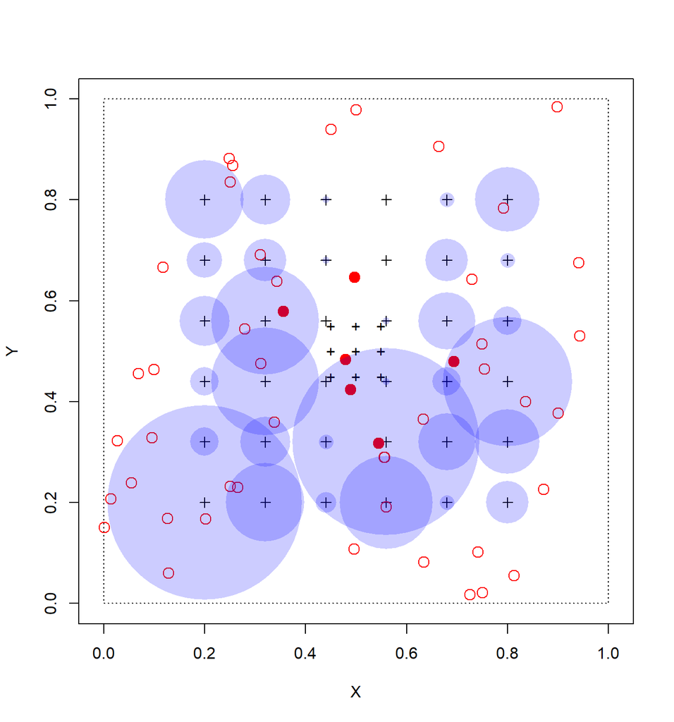

```r
plot(xm, pch="+", xlim=xlim, ylim=ylim, xlab="X", ylab="Y", asp=1)
points(xr, pch=3)  # Dispositivos sw reavistamiento (cámaras-trampa)
rect(xlim[1], ylim[1], xlim[2], ylim[2], lty=3)
points(s, pch=1, cex=1.5, col="red")  # Ubicación de los centros de actividad (CA)
points(s[marked,], pch=16, cex=1.5, col="red") # CA de marcados
points(xr, cex=n, pch=16, col=rgb(0,0,1,0.2)) # Algunos marcados y otros no
```

```r
M <- 200

## Preparación de datos de marcaje
ym.aug <- array(0L, c(M, Jm))
ym.aug[1:nrow(ym.obs),] <- ym.obs

## Preparación de datos de reavistamiento
yr.aug <- array(0L, c(M, Jr))
yr.aug[1:nrow(yr.obs),] <- yr.obs
```

## Código gSMR

```r
## define the model
code <- nimbleCode({

  p0m ~ dunif(0,1)
  sig ~ dunif(0,2)
  sig2 <- 2*sig^2
  lam0r ~ dunif(0,5)
  psi ~ dbeta(1,1)

  for(i in 1:M) {
    s[i,1] ~ dunif(xlim[1], xlim[2])
    s[i,2] ~ dunif(ylim[1], ylim[2])
    z[i] ~ dbern(psi)
    # Detección en trampas de marcaje
    pm[i,1:Jm] <- GetDetectionRate(s = s[i,1:2], X = xm[1:Jm,1:2], J=Jm, sigma=sig, lam0=p0m, z=z[i])
    # Detección en cámaras-trampa
    lamr[i,1:Jr] <- GetDetectionRate(s = s[i,1:2], X = xr[1:Jr,1:2], J=Jr, sigma=sig, lam0=lam0r, z=z[i])

    ## Datos en las ocasiones de marcaje (para N latente)
    for(j in 1:Jm) {
      ym[i,j] ~ dbinom(pm[i,j],KTm)
    }
  }

  ## Datos en las ocasiones de reavistamiento de marcados (1:nMarked)
  for(i in 1:nMarked) {
    for(j in 1:Jr) {
      yr[i,j] ~ dpois(lamr[i,j]*KTr) # Aquí z se aplica a 1:nMarked
    }
  }

  ## Conteo de animales no marcados (desde n:Marked hasta N latente)
  for(j in 1:Jr) {
    # Si podemos suponer que no hay variación temporal, sumamos:
    Lam[j] <- sum(lamr[((nMarked+1):M),j])# lamrz desde nMarked:M
    n[j] ~ dpois(Lam[j]*KTr)
  }

  N <- sum(z[1:M])
})
```

Cargamos el muestreador y la función de Augustine (2022)

```r
# Muestreador
source("sSampler.R")

# Función
GetDetectionRate <- nimbleFunction(
  run = function(s = double(1), lam0=double(0), sigma=double(0),
                 X=double(2), J=double(0), z=double(0)){
    returnType(double(1))
    if(z==0) return(rep(0,J))
    if(z==1){
     d2 <- ((s[1]-X[1:J,1])^2 + (s[2]-X[1:J,2])^2)
     ans <- lam0*exp(-d2/(2*sigma^2))
     return(ans)
    }
  }
)
```

## Preparamos constantes, datos e inicios

Preparamos las constantes:

```r
str(constants<-list(Jm=Jm,            # Número de dispositivos de captura
                    Jr=Jr,            # Número de dispositivos de reavistamiento
                    KTm=KTm,          # número de ocasiones de marcaje
                    KTr=KTr,          # número de ocasiones de reavistamiento
                    M=M,              # Aumentado de datos
                    nMarked=nMarked)) # Número de marcados
```

```
## List of 6
##  $ Jm     : int 9
##  $ Jr     : int 36
##  $ KTm    : num 10
##  $ KTr    : num 20
##  $ M      : num 200
##  $ nMarked: int 6
```

… los datos…

```r
str(data   <-  list(xm=xm,            # Coordenadas de dispositivos de captura
                    xr=xr,            # Coordenadas de dispositivos de reavistamiento
                    xlim=xlim,        # Límites (X) del espacio de estados
                    ylim=ylim,        # Límites (Y) del espacio de estados
                    ym=ym.aug,        # Historial de marcado, aumentado
                    yr=yr.aug,        # Historial de reavistamiento, aumentado
                    n=n))             # Conteos de animales no marcados
```

```
## List of 7
##  $ xm  : num [1:9, 1:2] 0.45 0.45 0.45 0.5 0.5 0.5 0.55 0.55 0.55 0.45 ...
##  $ xr  : num [1:36, 1:2] 0.2 0.2 0.2 0.2 0.2 0.2 0.32 0.32 0.32 0.32 ...
##  $ xlim: int [1:2] 0 1
##  $ ylim: int [1:2] 0 1
##  $ ym  : int [1:200, 1:9] 0 0 0 0 0 0 0 0 0 0 ...
##  $ yr  : int [1:200, 1:36] 0 0 0 0 0 0 0 0 0 0 ...
##  $ n   : num [1:36] 27 4 4 7 5 11 11 7 15 15 ...
```

… y los inicios. Para un correcto funcionamiento, generamos un conjunto de $M$ coordenadas de centros de actividad en el espacio de estados (*s.start*), y $M$ valores de *z* que para evitar contradecir la realidad, vamos a darle sólo valores de “1”. Los valores de inicio restantes los generamos al azar con funciones uniformes, de forma que sean compatibles con la información a *a priori* del código:

```r
s.start <- cbind(runif(M, xlim[1], xlim[2]), runif(M, ylim[1], ylim[2]))
zd <- rep(1,M)
str(inits  <-  list(z=zd,
                    s=s.start,
                    psi=runif(1,0,1),
                    p0m=runif(1,0,1),
                    lam0r=runif(1,0,1),
                    sig=runif(1,0,2)))
```

```
## List of 6
##  $ z    : num [1:200] 1 1 1 1 1 1 1 1 1 1 ...
##  $ s    : num [1:200, 1:2] 0.087 0.871 0.356 0.724 0.441 ...
##  $ psi  : num 0.662
##  $ p0m  : num 0.628
##  $ lam0r: num 0.264
##  $ sig  : num 0.502
```

Parámetros que vamos a monitorizar

```r
params <- c("psi", "p0m", "lam0r", "sig", "N")
```

## Compilamos y ejecutamos:

```r
Rmodel <- nimbleModel(code=code, constants=constants, data=data, inits=inits)
```

```
## Defining model
```

```
## Building model
```

```
## Setting data and initial values
```

```
## Running calculate on model
##   [Note] Any error reports that follow may simply reflect missing values in model variables.
```

```
## Checking model sizes and dimensions
```

```r
Rmodel$initializeInfo()  # Conveniente para ver los inicios
```

```
##   [Note] All model variables are initialized.
```

```r
Rmodel$calculate()
```

```
## [1] -34674.23
```

```r
Cmodel <- compileNimble(Rmodel)
```

```
## Compiling
##   [Note] This may take a minute.
##   [Note] Use 'showCompilerOutput = TRUE' to see C++ compilation details.
```

```r
conf<-configureMCMC(Rmodel, monitors=params)
```

```
## ===== Monitors =====
## thin = 1: lam0r, N, p0m, psi, sig
## ===== Samplers =====
## RW sampler (403)
##   - p0m
##   - sig
##   - lam0r
##   - s[]  (400 elements)
## conjugate sampler (1)
##   - psi
## binary sampler (200)
##   - z[]  (200 elements)
```

```r
conf$removeSampler(paste("s[1:",M,", 1:2]", sep=""))
for(i in 1:M){
  conf$addSampler(target = paste("s[",i,", 1:2]", sep=""),
                  type = 'sSampler',
                  control=list(i=i,
                               xlim=Rmodel$xlim,
                               ylim=Rmodel$ylim,
                               scale=0.25),
                  silent = TRUE)
}

MCMC <- buildMCMC(conf)

CompMCMC <- compileNimble(MCMC, project = Rmodel)
```

```
## Compiling
##   [Note] This may take a minute.
##   [Note] Use 'showCompilerOutput = TRUE' to see C++ compilation details.
```

```r
nb = 1000
ni = 5000 + nb
nc = 3

start.time2<-Sys.time()
outNim <- runMCMC(CompMCMC, niter = ni , nburnin = nb , nchains = nc,inits=inits,
                  setSeed = FALSE, progressBar = TRUE, samplesAsCodaMCMC = TRUE)
```

```
## Running chain 1 ...
```

```
## |-------------|-------------|-------------|-------------|
## |-------------------------------------------------------|
```

```
## Running chain 2 ...
```

```
## |-------------|-------------|-------------|-------------|
## |-------------------------------------------------------|
```

```
## Running chain 3 ...
```

```
## |-------------|-------------|-------------|-------------|
## |-------------------------------------------------------|
```

```r
end.time<-Sys.time()
end.time-start.time2 # tiempo de ejecución
```

```
## Time difference of 12.85986 mins
```

## Resultados

Compararemos lo simulado con los valores posteriores, y así podemos tener una idea de que tal funciona nuestro modelo.

```r
summary(outNim)
```

```
##
## Iterations = 1:5000
## Thinning interval = 1
## Number of chains = 3
## Sample size per chain = 5000
##
## 1. Empirical mean and standard deviation for each variable,
##    plus standard error of the mean:
##
##           Mean       SD  Naive SE Time-series SE
## N     47.60227 6.991004 5.708e-02      0.1500914
## lam0r  0.49945 0.062549 5.107e-04      0.0027559
## p0m    0.17757 0.042269 3.451e-04      0.0009958
## psi    0.24053 0.045704 3.732e-04      0.0008417
## sig    0.05545 0.002452 2.002e-05      0.0001007
##
## 2. Quantiles for each variable:
##
##           2.5%     25%      50%      75%    97.5%
## N     35.00000 43.0000 47.00000 52.00000 63.00000
## lam0r  0.38988  0.4538  0.49438  0.54145  0.63043
## p0m    0.10466  0.1477  0.17364  0.20356  0.26882
## psi    0.15868  0.2085  0.23826  0.26950  0.33749
## sig    0.05079  0.0538  0.05538  0.05708  0.06045
```

## Chequeamos convergencia de las cadenas de Markov

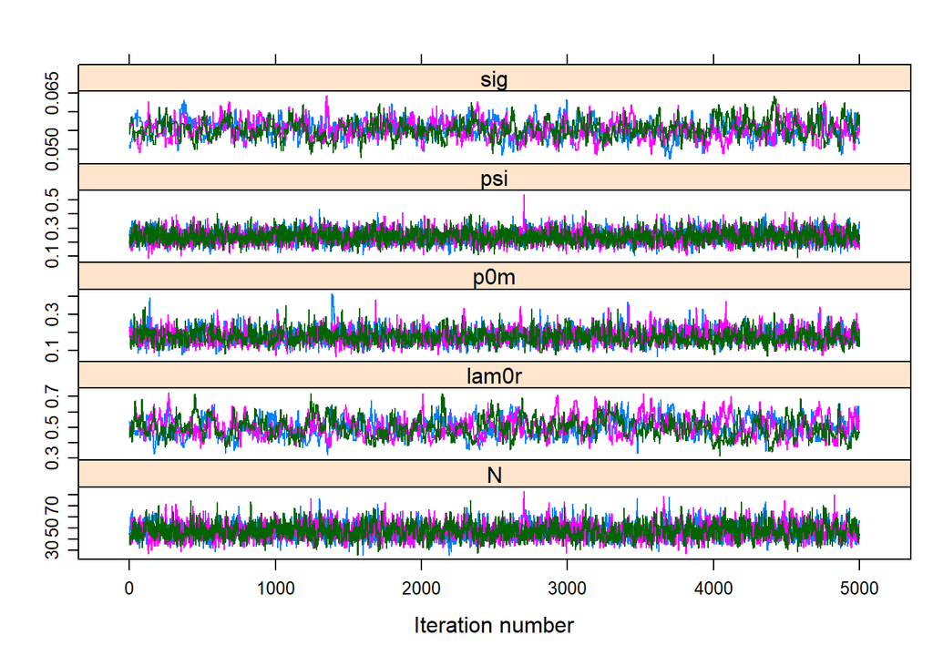

```r
#diagPlot(outNim)
xyplot(outNim)
```

## Referencias

Augustine, B. (2022). UnmarkedSCR. sSampler. Retrieved from https://github.com/benaug/UnmarkedSCR/blob/main/sSampler.R/.

Jiménez, J., Chandler, R. B., Tobajas, J., Descalzo, E., Mateo, R., & Ferreras, P. (2019). Generalized spatial mark–resight models with incomplete identification: An application to red fox density estimates. *Ecology and Evolution, 9*(8), ece3.5077. doi:10.1002/ece3.5077

R Core Team. (2022). R: A language and environment for statistical computing. R Foundation for Statistical Computing. Vienna, Austria. Retrieved from https://www.r-project.org/.

Royle, J. A., Chandler, R. B., Sollmann, R., & Gardner, B. (2014). *Spatial capture-recapture*. Waltham, Massachusetts: Elsevier, Academic Press. doi:10.1016/B978-0-12-405939-9.00026-8

Sollmann, R., Gardner, B., Parsons, A. W., Stocking, J. J., Mcclintock, B. T., Simons, T. R., … O’Connell, A. F. (2013). A spatial mark-resight model augmented with telemetry data. *Ecology, 94*(3), 553–559. doi:10.1890/12-1256.1

Whittington, J., Hebblewhite, M., & Chandler, R. B. (2017). Generalized spatial mark-resight models with an application to grizzly bears. *Journal of Applied Ecology, 55*(1), 1–12. doi:10.1111/1365-2664.12954